# R Notebook

**Explanation:** - This R Notebook chunk is labeled “Download and Read Dataset” for clarity. - The `echo=TRUE` argument is used to include the code in the output. - The code checks if the ‘downloader’ package is installed and installs it if not. - The ‘downloader’ package is loaded. - The dataset is downloaded from the specified URL and saved with the filename “mice_pheno.csv”. - The dataset is then read into a data frame named ‘dat’ using the `read.csv` function.

```r
# Load the 'downloader' package if not already installed
if (!requireNamespace("downloader", quietly = TRUE)) {
  install.packages("downloader")
}
library(downloader)

# Download the dataset
url <- "https://raw.githubusercontent.com/genomicsclass/dagdata/master/inst/extdata/mice_pheno.csv"
filename <- "mice_pheno.csv"
download(url, destfile = filename)
# Read the dataset into a data frame
dat <- read.csv(filename)

dat%>%skim()
```

```
── Data Summary ────────────────────────
                           Values
Name                       Piped data
Number of rows             846
Number of columns          3
_______________________
Column type frequency:
  character                2
  numeric                  1
________________________
Group variables            None
```

|  | skim_variable | n_missing | complete_rate | min | max | empty | n_unique | whitespace |
| --- | --- | --- | --- | --- | --- | --- | --- | --- |
| 1 | Sex | 0 | 1 | 1 | 1 | 0 | 2 | 0 |
| 2 | Diet | 0 | 1 | 2 | 4 | 0 | 2 | 0 |

|  | skim_variable | n_missing | complete_rate | mean | sd | p0 | p25 | p50 | p75 | p100 | hist |
| --- | --- | --- | --- | --- | --- | --- | --- | --- | --- | --- | --- |
| 1 | Bodyweight | 5 | 0.9940898 | 28.84705 | 6.260429 | 15.51 | 24.04 | 28.19 | 32.95 | 54.08 | ▃▇▅▁▁ |

**Explanation:** - This R Notebook chunk is labeled “Data Filtering and Descriptive Statistics” for clarity. - The `echo=TRUE` argument is used to include the code in the output. - The required ‘dplyr’ library is loaded. - The dataset is filtered to create two populations based on specified criteria. - The means of the filtered populations are calculated. - The difference in means is printed.

```r
# Load the required libraries
library(dplyr)

# Filter the dataset to create populations based on criteria
controlPopulation <- filter(dat,Sex == "F" & Diet == "chow") %>%
  select(Bodyweight) %>% unlist
hfPopulation <- filter(dat,Sex == "F" & Diet == "hf") %>%
  select(Bodyweight) %>% unlist
# Calculate means of the populations
mu_hf <- mean(hfPopulation)
mu_control <- mean(controlPopulation)

# Print the difference in means
print(mu_hf - mu_control)
```

```
[1] 2.375517
```

**Explanation:** - This R Notebook chunk is labeled “Variance Calculation and Comparison” for clarity. - The `echo=TRUE` argument is used to include the code in the output. - The population variance is calculated using the formula $\frac{1}{N} \sum_{i=1}^{N} (x_i - \bar{x})^2$, where $N$ is the length of the population. - The code checks if the variance calculated using the `var()` function is identical to the calculated population variance. - The code also checks if the adjusted variance ($\frac{N-1}{N} \times \text{var}(x)$) is identical to the calculated population variance.

```r
# Assign controlPopulation to variable x
x <- controlPopulation

# Get the length of x
N <- length(x)

# Calculate population variance
populationvar <- mean((x - mean(x))^2)

# Check if the variance calculated using var() is identical to the population variance
identical(var(x), populationvar)
```

```
[1] FALSE
```

```r
# Check if the adjusted variance is identical to the population variance
identical(var(x) * (N - 1) / N, populationvar)
```

```
[1] TRUE
```

```r
library(rafalib)
sd_hf <- popsd(hfPopulation)
sd_control <- popsd(controlPopulation)
```

**Explanation:** - This R Notebook chunk is labeled “Sampling and Simulation” for clarity. - The `echo=TRUE` argument is used to include the code in the output. - A sample size $N$ is set for the hf and control populations. - Random samples of size $N$ are created from hfPopulation and controlPopulation. - A vector `Ns` is defined, representing different sample sizes for simulations. - The number of simulations ($B$) is set to 10000. - Simulations are performed using the `sapply` function, calculating the differences in means for each sample size and replicating the process for 10000 times. The results are stored in the `res` matrix.

```r
# Set the sample size for hf and control populations
N <- 12

# Create random samples from hfPopulation and controlPopulation
hf <- sample(hfPopulation, N)
control <- sample(controlPopulation, N)

# Define a vector of different sample sizes (Ns)
Ns <- c(3, 12, 25, 50)

# Set the number of simulations (B)
B <- 10000

# Perform simulations to calculate differences in means for each sample size
res <- sapply(Ns, function(n) {
  replicate(B, mean(sample(hfPopulation, n)) - mean(sample(controlPopulation, n)))
})
```

**Explanation:** - This R Notebook chunk is labeled “QQ Plots for Simulated Differences in Means” for clarity. - The `echo=TRUE` argument is used to include the code in the output. - A custom function `mypar` is defined to set the layout using `par` for a 2x2 plot. - The layout is set using `mypar(2, 2)`. - A loop is used to iterate through different sample sizes (`Ns`). - For each sample size, the average and standard deviation of the simulated differences in means are calculated for titles. - QQ plots are created using `qqnorm` and `qqline` to visualize the distribution of the simulated differences in means. Each plot corresponds to a different sample size.

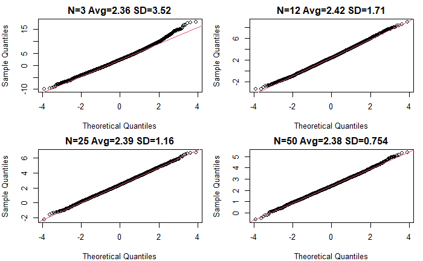

```r
# Define a custom par function (mypar)
mypar <- function(nr, nc) {
  par(mfrow = c(nr, nc), mar = c(4, 4, 2, 1))
}

# Set the layout for a 2x2 plot
mypar(2, 2)

# Loop through different sample sizes
for (i in seq(along = Ns)) {
  # Calculate average and standard deviation for titles
  titleavg <- signif(mean(res[, i]), 3)
  titlesd <- signif(sd(res[, i]), 3)
  title <- paste0("N=", Ns[i], " Avg=", titleavg, " SD=", titlesd)

  # Create QQ plots
  qqnorm(res[, i], main = title)
  qqline(res[, i], col = 2)
}
```

**Explanation:** - This R Notebook chunk is labeled “QQ Plots for Simulated t-Statistic” for clarity. - The `echo=TRUE` argument is used to include the code in the output. - A custom function `mypar` is defined to set the layout using `par` for a 2x2 plot. - The sample sizes (`Ns`) and the number of simulations (`B`) are set. - A function `computetstat` is defined to compute a t-statistic for given sample sizes. - Simulations are performed using `sapply` to calculate t-statistics for each sample size and replicate the process for 10000 times. The results are stored in the `res` matrix. - QQ plots are created using `qqnorm` and `qqline` to visualize the distribution of the simulated t-statistics. Each plot corresponds to a different sample size.

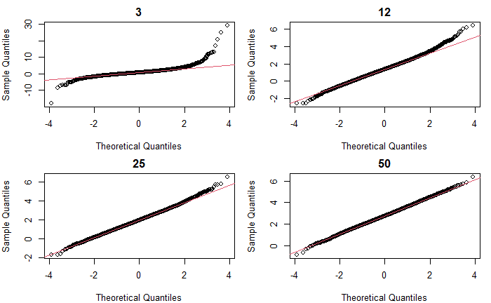

```r
# Define a custom par function (mypar)
mypar <- function(nr, nc) {
  par(mfrow = c(nr, nc), mar = c(4, 4, 2, 1))
}

# Set the sample sizes (Ns) and number of simulations (B)
Ns <- c(3, 12, 25, 50)
B <- 10000

# Function to compute a t-statistic
computetstat <- function(n) {
  y <- sample(hfPopulation, n)
  x <- sample(controlPopulation, n)
  (mean(y) - mean(x)) / sqrt(var(y) / n + var(x) / n)
}

# Perform simulations to compute t-statistics for each sample size
res <- sapply(Ns, function(n) {
  replicate(B, computetstat(n))
})

# Set the layout for a 2x2 plot
mypar(2, 2)

# Loop through different sample sizes
for (i in seq(along = Ns)) {
  # Create QQ plots for t-statistics
  qqnorm(res[, i], main = Ns[i])
  qqline(res[, i], col = 2)
}
```